# Analyzing and Processing Optimized Resistance Surfaces

Divyashree Rana

2026-07-05

This workflow reconstructs optimized resistance curves from ResistanceGA outputs, compares species-specific responses to landscape variables, and prepares resistance surfaces and habitat nodes for Circuitscape connectivity analyses.

The workflow consists of the following steps:

1. Load required packages
2. Define project directories
3. Summarize raster value ranges
4. Generate optimized resistance curves
5. Compare resistance curves among species
6. Prepare Circuitscape input rasters

# 1 Load required packages

The following packages are required for raster processing, data manipulation, visualization, and preparation of Circuitscape inputs.

```r
library(terra)
library(dplyr)
library(purrr)
library(tidyr)
library(ggplot2)
library(sf)
```

# 2 Define project directories

Input and output directories are defined once to simplify file management throughout the workflow.

```r
input_dir <- "./input/smooth"

results_dir <- "./results"

raster_dir_1km  <- file.path(input_dir, "rasters_1km")
raster_dir_2km  <- file.path(input_dir, "rasters_2km")
raster_dir_5km  <- file.path(input_dir, "rasters_5km")
raster_dir_10km <- file.path(input_dir, "rasters_10km")

species <- "FC"
```

# 3 Summarize raster value ranges

Optimized resistance functions are applied to raster values scaled between their observed minimum and maximum. Recording the range of each environmental predictor provides a reference for interpreting resistance transformations and confirms consistency across spatial scales.

## 3.1 Load raster surfaces

```r
raster_1km <- list.files(
  raster_dir_1km,
  pattern = "\\.asc$",
  full.names = TRUE
)

raster_2km <- list.files(
  raster_dir_2km,
  pattern = "\\.asc$",
  full.names = TRUE
)

raster_5km <- list.files(
  raster_dir_5km,
  pattern = "\\.asc$",
  full.names = TRUE
)

raster_10km <- list.files(
  raster_dir_10km,
  pattern = "\\.asc$",
  full.names = TRUE
)

all_rasters <- c(
  raster_1km,
  raster_2km,
  raster_5km,
  raster_10km
)
```

## 3.2 Define helper function

```r
get_range <- function(file){

  r <- rast(file)

  vals <- global(
    r,
    range,
    na.rm = TRUE
  )

  data.frame(
    file = basename(file),
    xmin = vals[1],
    xmax = vals[2]
  )

}
```

## 3.3 Calculate raster value ranges

```r
raster_ranges <-
  do.call(
    rbind,
    lapply(
      all_rasters,
      get_range
    )
  )

raster_ranges
```

```
##                                                                      file
## agri_dens_1km                                       agri_dens_1km_1km.asc
## dist_settlement_10m_utm_1km           dist_settlement_10m_utm_1km_1km.asc
## dist_water_30m_utm_1km                     dist_water_30m_utm_1km_1km.asc
## MODIS_EVI_rescaled_500m_utm_1km   MODIS_EVI_rescaled_500m_utm_1km_1km.asc
## agri_dens_1km1                                      agri_dens_1km_2km.asc
## dist_settlement_10m_utm_1km1          dist_settlement_10m_utm_1km_2km.asc
## dist_water_30m_utm_1km1                    dist_water_30m_utm_1km_2km.asc
## MODIS_EVI_rescaled_500m_utm_1km1  MODIS_EVI_rescaled_500m_utm_1km_2km.asc
## agri_dens_1km2                                      agri_dens_1km_5km.asc
## dist_settlement_10m_utm_1km2          dist_settlement_10m_utm_1km_5km.asc
## dist_water_30m_utm_1km2                    dist_water_30m_utm_1km_5km.asc
## MODIS_EVI_rescaled_500m_utm_1km2  MODIS_EVI_rescaled_500m_utm_1km_5km.asc
## agri_dens_1km3                                     agri_dens_1km_10km.asc
## dist_settlement_10m_utm_1km3         dist_settlement_10m_utm_1km_10km.asc
## dist_water_30m_utm_1km3                   dist_water_30m_utm_1km_10km.asc
## MODIS_EVI_rescaled_500m_utm_1km3 MODIS_EVI_rescaled_500m_utm_1km_10km.asc
##                                            X1           X2
## agri_dens_1km                    0.000000e+00 1.000000e+02
## dist_settlement_10m_utm_1km      5.413951e+00 7.772756e+03
## dist_water_30m_utm_1km           5.526969e-03 1.462090e+04
## MODIS_EVI_rescaled_500m_utm_1km  1.786986e-02 4.742385e-01
## agri_dens_1km1                   0.000000e+00 9.833234e+01
## dist_settlement_10m_utm_1km1     2.493630e+01 7.438030e+03
## dist_water_30m_utm_1km1          2.655099e+01 1.393329e+04
## MODIS_EVI_rescaled_500m_utm_1km1 9.269383e-02 4.443601e-01
## agri_dens_1km2                   3.050000e-03 9.538660e+01
## dist_settlement_10m_utm_1km2     8.359181e+01 6.194475e+03
## dist_water_30m_utm_1km2          2.420763e+02 1.266511e+04
## MODIS_EVI_rescaled_500m_utm_1km2 2.037030e-01 4.101105e-01
## agri_dens_1km3                   1.538535e-01 9.334245e+01
## dist_settlement_10m_utm_1km3     1.279425e+02 4.561650e+03
## dist_water_30m_utm_1km3          6.031252e+02 1.056635e+04
## MODIS_EVI_rescaled_500m_utm_1km3 2.463394e-01 3.893765e-01
```

```r
write.csv(
  raster_ranges,
  file.path(
    input_dir,
    "raster_range_summary.csv"
  ),
  row.names = FALSE
)
```

# 4 Generate optimized resistance curves

The optimized transformation parameters obtained from ResistanceGA are used to reconstruct resistance functions for each landscape variable. These curves describe how landscape characteristics are translated into movement resistance for each species.

## 4.1 Define resistance transformation functions

```r
mono <- function(x, shape, rmax){

  1 + (rmax - 1) *
    (
      (1 - exp(-shape * x)) /
      (1 - exp(-shape))
    )

}

inv_mono <- function(x, shape, rmax){

  1 + (rmax - 1) *
    (
      (exp(-shape * x) - exp(-shape)) /
      (1 - exp(-shape))
    )

}

rev_mono <- function(x, shape, rmax){

  1 + (rmax - 1) *
    (
      (1 - exp(-shape * (1 - x))) /
      (1 - exp(-shape))
    )

}

inv_rev_mono <- function(x, shape, rmax){

  1 + (rmax - 1) *
    (
      (exp(-shape * (1 - x)) - exp(-shape)) /
      (1 - exp(-shape))
    )

}
```

## 4.2 Generate resistance curves

Prepare file with curve parameters for optimized scales of each variable for each species here - ./results/landscape_variables_and_scale_optimized_resistance.csv with columns as “species” “variable” “scale” “equation” “shape” “rmax” “xmin” “xmax” and each row with a combination of species (s) and optimized variable (n). Hence, total rows = n*s

```r
params <- read.csv(
  file.path(
    results_dir,
    "landscape_variables_and_scale_optimized_resistance.csv"
  )
)

# Generate resistance curves

curve_data <- params %>%
  rowwise() %>%
  mutate(
    x_seq = list(seq(0, 1, length.out = 10000)),
    resistance = list({
      x <- x_seq
      s <- cur_data()$shape
      r <- cur_data()$rmax
      eq <- cur_data()$equation

      if (eq == "Monomolecular") {
        mono(x, s, r)
      } else if (eq == "Inverse Monomolecular") {
        inv_mono(x, s, r)
      } else if (eq == "Reverse Monomolecular") {
        rev_mono(x, s, r)
      } else if (eq == "Inverse-Reverse Monomolecular") {
        inv_rev_mono(x, s, r)
      }
    })
  ) %>%
  unnest(cols = c(x_seq, resistance)) %>%
  rename(x_value = x_seq)
```

# 5 Compare resistance curves among species

Species-specific resistance curves are compared to evaluate similarities and differences in landscape responses. Small offsets are applied to the x-axis only for visualization, reducing overlap among nearly identical curves while preserving their overall shapes.

```r
curve_data <- curve_data %>%
  group_by(species, variable) %>%
  mutate(res_scaled =
           (resistance - min(resistance)) /
           (max(resistance) - min(resistance)))

curve_data <- curve_data %>%
  mutate(
    species = factor(species, levels = c("TG", "LP", "JC", "FC", "SB"))
  )

offset_map <- c(
  "TG" = -0.02,
  "LP" = -0.01,
  "JC" =  0.00,
  "FC" =  0.01,
  "SB" =  0.02
) #to avoid overlapping slopes while retaining there shapes and strength
curve_data <- curve_data %>%
  mutate(
    x_jitter = x_value + offset_map[species]
  )

write.csv(curve_data, "./results/multispecies_resistance_curve_estimated_values.csv", row.names = F)
```

## 5.1 Plot comparative resistance curves

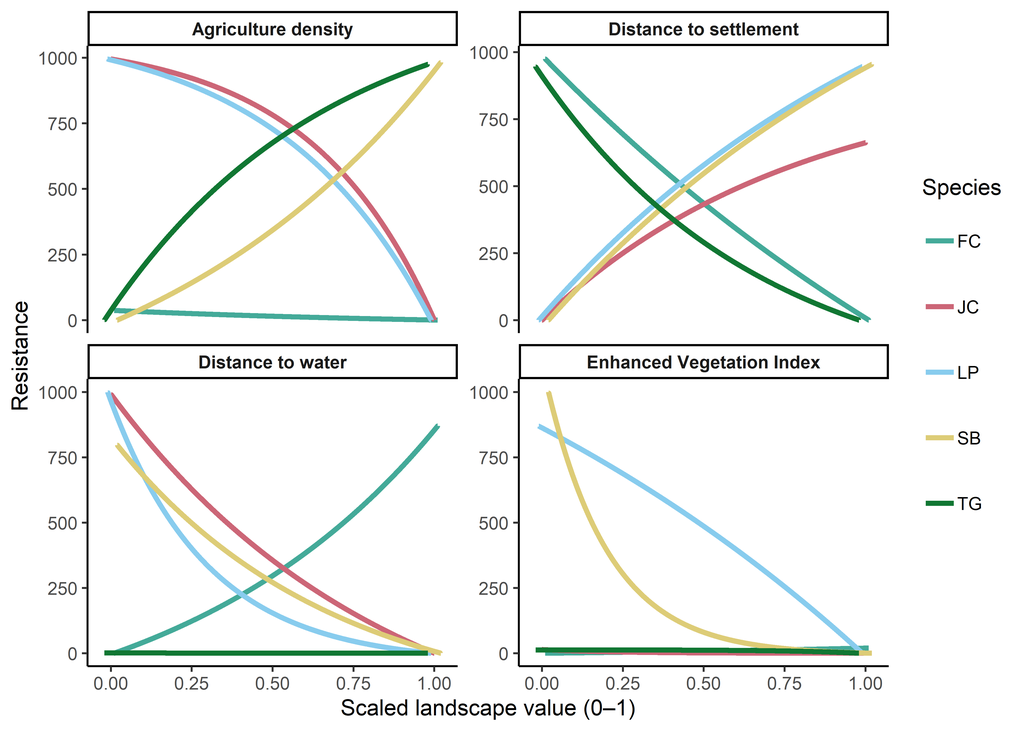

```r
curve_data = read.csv("./results/multispecies_resistance_curve_estimated_values.csv")

custom_labs <- c(
  "Agriculture_density" = "Agriculture density",
  "Distance_settlement" = "Distance to settlement",
  "Distance_water" = "Distance to water",
  "EVI" = "Enhanced Vegetation Index"
)

ggplot(curve_data,
       aes(x = x_jitter,
           y = resistance,
           colour = species,
           group = interaction(species, variable))) +
  geom_line(linewidth = 1.2) +
  facet_wrap(~ variable, scales = "free_y", labeller = labeller(variable = custom_labs)) +
  theme_classic() +
  theme(strip.text = element_text(face = "bold"))+
  guides(colour = guide_legend(
    byrow = TRUE,
    label.theme = element_text(margin = margin(t = 12, b = 12)))) +
  scale_colour_manual(values = c(
    "TG" = "#117733",  # green
    "LP" = "#88CCEE",  # blue
    "JC" = "#CC6677",  # pink
    "FC" = "#44AA99",  # teal (replaces yellow-green #BECF5F)
    "SB" = "#DDCC77"   # soft yellow (cleaner than orange #D9A441)
  )) +
  labs(x = "Scaled landscape value (0–1)",
       y = "Resistance",
       colour = "Species")
```

```r
ggsave("./results/plot/multispecies_resistance_curves.png", width = 10, height = 8, units = "in", dpi = 300)
```

# 6 Prepare Circuitscape input rasters

Optimized resistance surfaces and habitat nodes are converted into aligned ASCII rasters suitable for Circuitscape analyses. All spatial layers must share an identical coordinate reference system, extent, resolution, and cell alignment before connectivity modelling.

## 6.1 Rasterize protected area nodes

```r
# Load node shapefile
nodes <- vect("./results/Central_terai_PA.shp")
crs(nodes) <- "EPSG:4326"

# Load one of your existing rasters as template
template <- rast("./input/rasters_1km/agri_dens_1km.asc")

nodes_utm <- project(nodes, template)

crs(nodes_utm)
```

```
## [1] "PROJCRS[\"WGS 84 / UTM zone 44N\",\n    BASEGEOGCRS[\"WGS 84\",\n        DATUM[\"World Geodetic System 1984\",\n            ELLIPSOID[\"WGS 84\",6378137,298.257223563,\n                LENGTHUNIT[\"metre\",1]],\n            ID[\"EPSG\",6326]],\n        PRIMEM[\"Greenwich\",0,\n            AN…
```

```r
crs(template)
```

```
## [1] "PROJCRS[\"WGS 84 / UTM zone 44N\",\n    BASEGEOGCRS[\"WGS 84\",\n        DATUM[\"World Geodetic System 1984\",\n            ELLIPSOID[\"WGS 84\",6378137,298.257223563,\n                LENGTHUNIT[\"metre\",1]],\n            ID[\"EPSG\",6326]],\n        PRIMEM[\"Greenwich\",0,\n            AN…
```

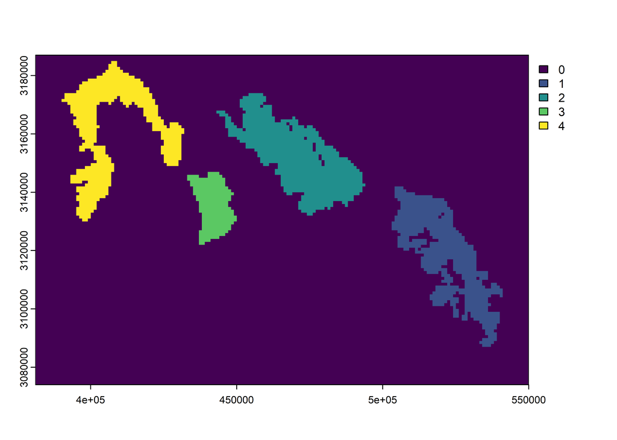

```r
nodes_utm$ID <- 1:nrow(nodes)
nodes_rast <- rasterize(
  nodes_utm,
  template,
  field = "ID",
  background = 0,
  touches = TRUE
)

nodes_rast[is.na(nodes_rast)] <- 0

plot(nodes_rast)
```

```r
writeRaster(nodes_rast, "./results/Central_terai_PA_1km.asc", overwrite = TRUE)
```

## 6.2 Align resistance and node rasters

The optimized resistance surface is cropped and aligned with the habitat node raster to ensure identical geometry for Circuitscape analyses. In res_rast assign the optimized multisurface with least AIC, selected by the model for creating circuitscale input.

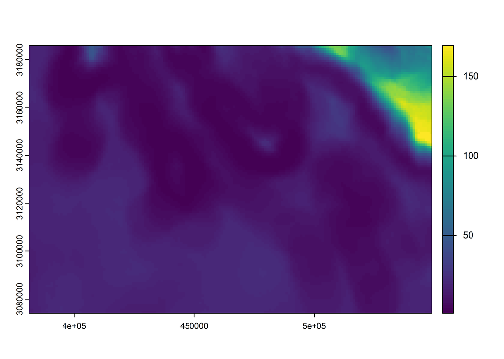

```r
# Read resistance raster
res_rast <- rast("./results/FC_subset1_resistance_surface.asc")

# Pick UTM zone based on your study area (e.g., EPSG:32644 for UTM zone 44N)
crs(res_rast) <- "EPSG:32644"

# Cropping extent with no value - top and right one row cell

# Get original extent
ext_res <- ext(res_rast)

new_ext <- ext(
  ext_res$xmin,
  ext_res$xmax - res(res_rast)[1],  # subtract cell size in x
  ext_res$ymin,
  ext_res$ymax - res(res_rast)[2]   # subtract cell size in y
)

# Crop raster
res_rast_cropped <- crop(res_rast, new_ext)
plot(res_rast_cropped)
```

```r
# Reproject node shapefile
node <- rast("./results/Central_terai_PA_1km.asc")

# Align node raster to resistance raster
node_aligned <- resample(node, res_rast_cropped, method = "near")

# Replace NA with 0 (background)
node_fixed <- classify(node_aligned, cbind(NA, 0))
```

## 6.3 Verify raster geometry

```r
compareGeom(
  res_rast_cropped,
  node_fixed,
  stopOnError = TRUE
)
```

```
## [1] TRUE
```

## 6.4 Export Circuitscape inputs

```r
writeRaster(
  res_rast_cropped,
  file = file.path(
    results_dir,
    paste0(
      species,
      "_subset1_resistance_UTM.asc"
    )
  ),
  overwrite = TRUE
)

writeRaster(
  node_fixed,
  file = file.path(
    results_dir,
    "Central_terai_PA_1km_fixed.asc"
  ),
  overwrite = TRUE
)
```